# Handwriting Analysis: Writer Identification and Verification

Writer identification with a CNN and writer verification with a Siamese network

## Introduction

This report studies a simulated dataset of 25,000 handwritten digits (0–4) written by 20 people, each of whom completed five recording sessions. Every person has a recognisable style, but their writing shifts somewhat between sessions. The aim is to find out how well neural networks can recognise a writer from their handwriting, and what limits that ability.

We approach the problem in two ways. A convolutional neural network (CNN) is trained for **writer identification**: given one image, which of the 20 writers produced it? A Siamese network is trained for **writer verification**: given two images, were they written by the same person? Throughout, models are trained on sessions 1–3, tuned on session 4 and tested on session 5, so every result measures performance on handwriting from a session the model has not seen.

Section 1 explores the images and the sources of variation in the data. Sections 2 and 3 build and evaluatees each model. Section 4 justifies the session-based data split, and Section 5 tests how sensitive each model is to its hyperparameters. Section 6 compares the two models, examines which digits carry the most writer information, and assesses how session changes affect performance.

## Section 1: Exploratory Data Analysis

### Global Dataset Profile overview

The handwriting dataset evaluated in this study constitutes a completely uniform, synthetically balanced array designed for writer identification and verification tasks. It contains a total population of 25,000 unique images mapped across a multi-dimensional recording matrix. The underlying data distribution is structured as follows:

- **Writers (20):** Represented by `person_id` ranging from 1 to 20.
- **Characters (5):** Represented by `digit` spanning 0 to 4.
- **Temporal Intervals (5):** Represented by `session` tracking blocks 1 to 5.
- **Replicate Volume (50):** Represented by `replicate` indicating repeated frames from 1 to 50 captured sequentially within a single sitting.

The data collection is entirely free from any structural class imbalances as it contains exactly 50 replicates for every single intersecting combination of person, digit, and session ($20 \times 5 \times 5 \times 50 = 25,000$). This perfect alignment avoids standard sampling biases,thus overall accuracy metrics will remain uninflated by majority-class dominance.

The raw data image is formatted as integer elements ranging from 0 (representing the blank background canvas) to 255 (representing the maximum ink density path). The image pixel values were scaled to [0,1] before fitting the models as it will cause numerical instability during early backpropagation rounds.

Moreover, each person has a consistent handwriting style, but their writing style fluctuates between the 5 recording due to various factors - different writing materials or natural variation.

### Analysis of Visible Sources of Variation

#### Inter-Writer Style Variation

In order to examine the inter-writer style variation the single character class (digit 0) across the first 5 writers is analysed in the figure below. It is evident that there is a clear variation in the writing style of each writer. For instance, writer 1’s character leans towards the left with an asymmetrical top loop whereas writer 2 produces uniform stroke borders with flat horizontal loops. Furthermore, writer 3 produces a small, pinched dense circle unlike writers 4 and 5 with larger round circles where writer 4 is less symmetrical than writer 5. These differences act as key identity signals that convolutional filters can easily latch onto to identify writers.

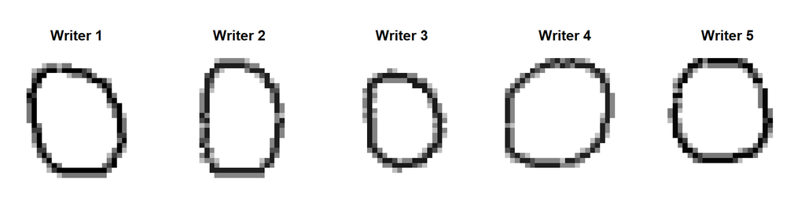

Figure 1: Digit 0 written by Writers 1 to 5 (inter-writer style variation)

#### Consistent Individual Handwriting Signatures

When tracking multiple characters produced by a single hand, a cohesive, cross-character fingerprint becomes apparent. For example, evaluating Writer 1 the writer maintains a perfectly upright, non-slanted angle across all stroke length. Conversely, when evaluating writer 10 in session 5 it is evident that the writer sustains a slanted angle to the right across all digits. This verifies that personal writing styles carry over into different character geometries.

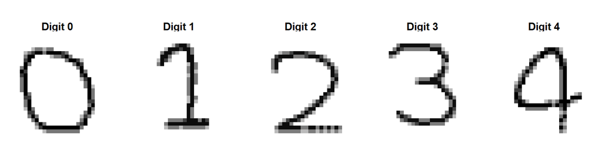

Figure 2: Digits 0 to 4 written by Writer 1 (consistent individual signature)

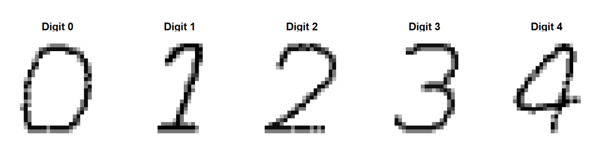

Figure 3: Digits 0 to 4 written by Writer 10 (consistent individual signature)

#### Temporal Session Drift

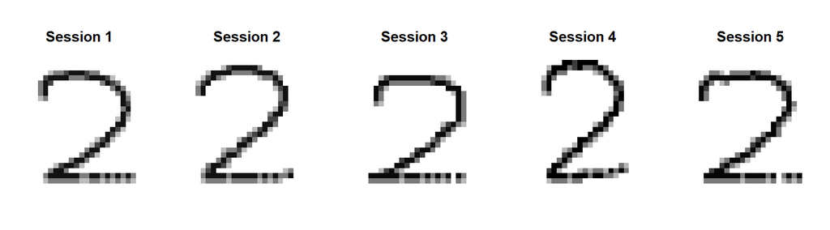

Figure 4: Digit 2 by Writer 1 across Sessions 1 to 5 (temporal drift)

### Limitations of the Simulated Data

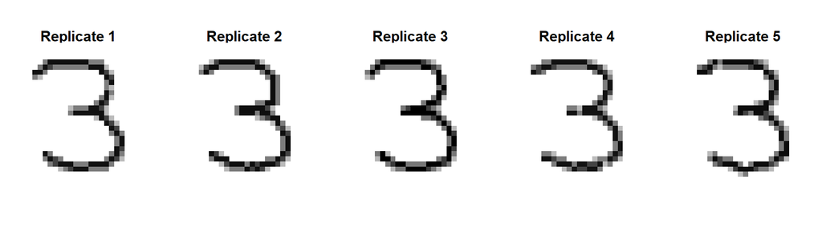

Figure 5: Digit 3 by Writer 1, Session 1, Replicates 1 to 5

The exploration shows that each writer has a recognisable style that carries across digits, but that this style shifts between sessions, while repeated samples within a session are almost identical. These observations shape the modelling that follows.

## Section 2: CNN Writer Identification

### Prediction Task and Model

The aim was to identify which of the 20 writers produced a single handwritten digit image. Each input was a 28 × 28 greyscale image, and the response was the writer ID. The task was therefore a 20-class classification problem. Although the images contained digits 0–4, the model was trained to recognise the writer rather than the digit.

Pixel values were divided by 255 to scale them to between 0 and 1. Sessions 1–3 were used for training, session 4 for validation and session 5 for testing. This gave 15,000 training images, 5,000 validation images and 5,000 test images. All writers and digits were represented in each subset. This design evaluates whether the model can identify known writers in a different recording session. The reasons for choosing a session-based split are discussed further in Section 4.

The CNN contained two convolutional layers, with 32 and 64 filters respectively. Both used 3 × 3 kernels, same padding and ReLU activation, followed by 2 × 2 max pooling. These layers allow the model to learn local features, such as stroke shapes and curves, and combine them into features useful for distinguishing writers. The feature maps were flattened and passed through a dense layer with 128 ReLU units. An L2 penalty of 0.0001 was applied to the dense layer’s weights, followed by dropout with a rate of 0.5. These measures were included to reduce overfitting, although they do not guarantee that it will be avoided.

The final layer had 20 softmax units, producing a probability distribution over the writer IDs. The writer with the highest probability was selected as the prediction. The labels were converted from IDs 1–20 to indices 0–19 and one-hot encoded for training. The model used categorical cross-entropy with the Adam optimiser, a learning rate of 0.0001 and a batch size of 64. A random seed of 2026 was set before building the model.

Training was allowed to run for up to 15 epochs. Early stopping monitored validation loss, with patience of three epochs, and restored the weights from the epoch with the lowest validation loss. The validation session was therefore used to select the training duration.

### Training Behaviour

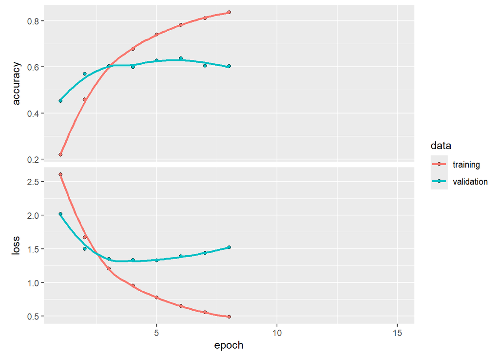

Figure 6: CNN training and validation accuracy and loss across the epochs run.

The model ran for 8 epochs, with the lowest validation loss of 1.3280 occurring at epoch 5. The weights from that epoch were restored for testing. The highest validation accuracy observed during training was 63.66%, at epoch 6. This was not necessarily the selected epoch because early stopping monitored validation loss rather than accuracy.

Figure 6 shows a widening gap between training and validation performance. Training accuracy increased from 21.86% in the first epoch to 83.63% in the final epoch. However, validation accuracy levelled off, while validation loss increased after its minimum. This pattern is consistent with overfitting: the model continued to improve on the training images, but the additional learning did not transfer well to the validation session. Session-specific features may contribute to this gap, although the curves alone cannot establish which features the model used.

Validation accuracy can remain similar while validation loss rises because loss also reflects the probabilities assigned to each class. A model can make approximately the same number of mistakes while becoming more confident in its incorrect predictions. The monitored loss also includes the L2 penalty. Early stopping limited further training once validation loss stopped improving; it did not cause the overfitting. The last point in the training curve describes the last epoch run, rather than the restored model used for the test predictions.

### Overall Test Performance

Table 1: CNN writer identification performance on the held-out test session.

| Measure | Value |
| --- | --- |
| Test images | 5000 |
| Correct writer predictions | 3277 |
| Accuracy (%) | 65.54 |
| Uniform guessing baseline (%) | 5.00 |
| Cohen’s kappa | 0.6373 |

The selected model correctly identified the writer for 3,277 of the 5,000 test images, giving an overall accuracy of **65.54%** (Table 1). In practical terms, this corresponds to correctly identifying the writer for approximately 66 out of every 100 test images. Accuracy is the proportion of images for which the predicted writer matches the actual writer.

Each writer contributed the same number of test images, so the overall result was not dominated by a more common writer. Uniform random guessing among the 20 writers would have an expected accuracy of 5%. The model therefore learned useful information for identifying writers, although it still incorrectly attributed 34.5% of the test images.

Cohen’s kappa was 0.6373. This measures agreement between predicted and actual writer IDs after accounting for agreement expected by chance from their marginal distributions. A value of 1 indicates perfect agreement and 0 indicates agreement at the chance level. Kappa provides an additional description of performance, but does not show whether all writers are identified equally well.

### Performance by Digit

Table 2: Writer identification accuracy by digit on the test set.

| Digit | Test images | Correct predictions | Accuracy (%) |
| --- | --- | --- | --- |
| 0 | 1000 | 634 | 63.4 |
| 1 | 1000 | 639 | 63.9 |
| 2 | 1000 | 619 | 61.9 |
| 3 | 1000 | 716 | 71.6 |
| 4 | 1000 | 669 | 66.9 |

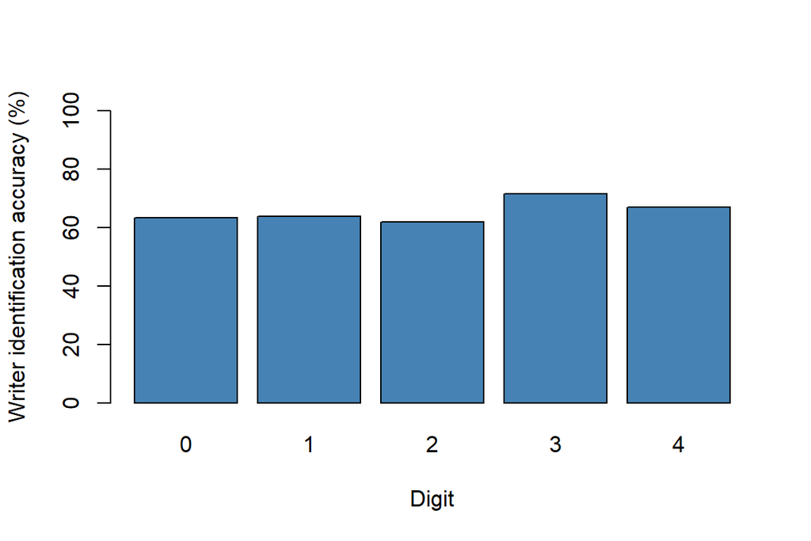

Figure 7: CNN writer identification accuracy for each digit in the test session.

Table 2 and Figure 7 compare writer identification accuracy separately for each digit. Each digit contributed 1,000 test images, with 50 from each writer, making the digit groups comparable in size and writer composition. The same trained CNN was used for all digits; separate models were not fitted for this comparison.

The highest accuracy was obtained for digit 3, at 71.6%. This was followed by digit 4, at 66.9%. The lowest accuracy was obtained for digit 2, at 61.9%. The difference between the highest and lowest values was 9.7 percentage points.

These results suggest that some digit shapes provided more useful writer-specific information to this CNN than others in the test session. Differences in stroke shape, slant or curvature could help distinguish writers, but this comparison does not establish which features caused the differences. Small differences between digits should also be interpreted cautiously, as no formal test of those differences was carried out.

Accuracy by digit measures how reliably the writer can be identified when a particular digit is presented. It does not measure whether the model can recognise the digit itself. A lower writer identification accuracy for a digit therefore does not mean that the digit was unreadable; it means that the model found it harder to distinguish who wrote it.

### Writer Confusions and Interpretation

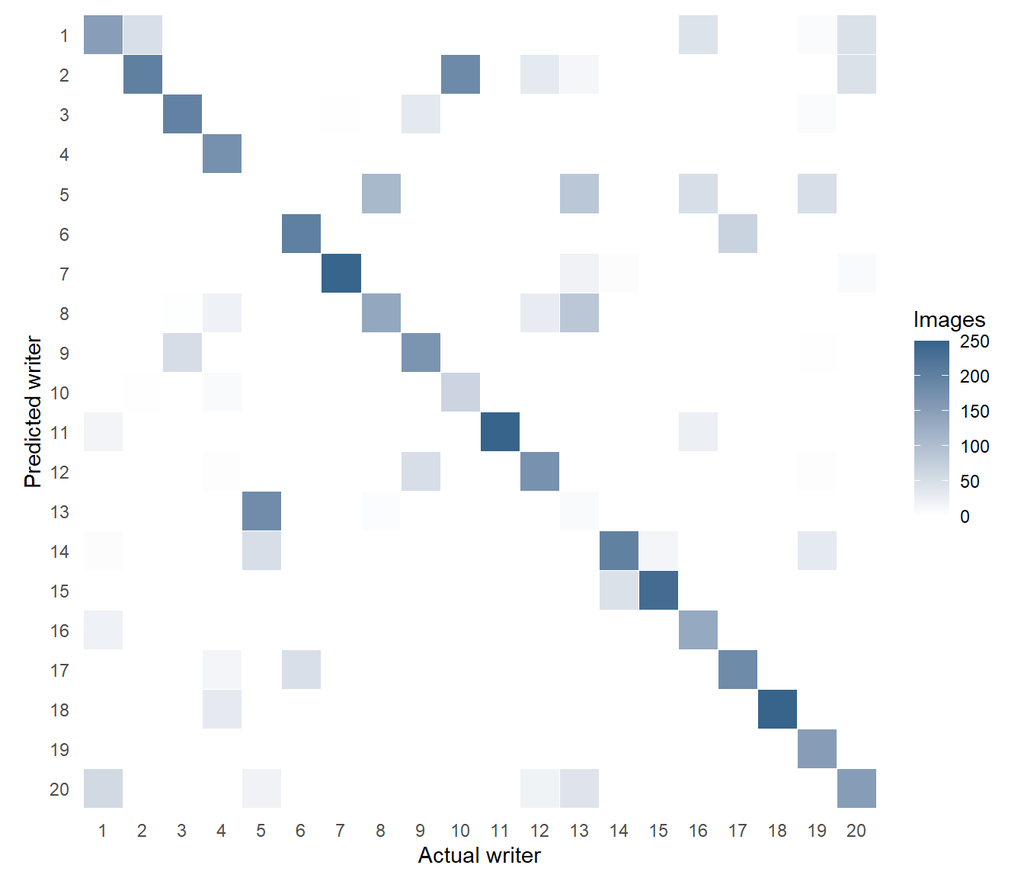

Figure 8: Writer confusion matrix: actual writer IDs on the horizontal axis and predicted writer IDs on the vertical axis.

In Figure 8, actual writer IDs appear on the horizontal axis and predicted IDs on the vertical axis. Diagonal cells represent correct predictions, while cells away from the diagonal show which writers were confused. The matrix shows that performance varied substantially between writers.

Writers 11 and 18 had recalls of 100.0% and 100.0%, respectively, whereas writer 5 had a recall of 0.0%. Writer 10 had a recall of 26.0%, with 185 of their 250 images attributed to writer 2. Similarly, 181 of writer 5’s images were attributed to writer 13. These examples show that the errors were concentrated in particular writer confusions rather than being evenly distributed across all classes.

Recall should be distinguished from precision. Recall asks how many of a writer’s own images were correctly recognised. Precision asks how many images assigned to that writer actually belonged to them. For example, writer 11’s precision was 86.5%. Even when all of a writer’s own images are recognised, some images from other writers may also be incorrectly assigned to that writer. This distinction matters if the model is used to attribute an image to a specific person.

The CNN provides a baseline for recognising these 20 writers across recording sessions. Its overall performance indicates that it learned useful distinctions between writers, but the training curves and confusion matrix also show limitations. Similar writing styles or changes between sessions could explain some errors, although additional analysis would be needed to distinguish these explanations.

The evaluation concerns new-session images from known writers. It does not measure the ability to identify a person who was absent from training, and the classifier will still choose one of the 20 IDs if presented with such a person. Testing on one held-out session also does not quantify how performance varies across other possible sessions. Finally, because the images were simulated, these results should not be taken as evidence of equivalent performance on real handwriting.

The CNN identified the correct writer for 65.5% of test images, far above the 5% expected by chance, but its errors were concentrated on a few writers, and it can only choose among the 20 people it was trained on. Section 3 takes a different approach. Rather than learning fixed writer labels, a Siamese network learns to judge whether two images come from the same person.

## Section 3: Writer Verification using a Siamese Network

The objective for this section is to develop and evaluate a Siamese neural network for writer verification, where the objective is to determine whether two handwritten digit images were produced by the same writer.

### Construction of Training Examples

Image pairs were generated with approximately equal proportions of same-writer and different-writer examples. Labels of 1 and 0 were assigned respectively. The realised proportions are reported in Table 3.

Table 3: Number of pairs and proportion of same-writer pairs in each split.

| Dataset | Number_of_Pairs | Positive_Pair_Proportion |
| --- | --- | --- |
| Training | 20000 | 0.4974 |
| Validation | 5000 | 0.4896 |
| Test | 5000 | 0.4918 |

### Shared Encoder Network

A convolutional neural network (CNN) was used as the shared encoder. The encoder consisted of three convolutional layers with ReLU activation functions and max-pooling layers for feature extraction. The encoder transformed each handwriting image into a compact feature representation that captured important writer characteristics.

### Siamese Network Architecture

The Siamese network contained two identical branches that shared the same encoder weights. Each branch processed one image from a pair. The feature vectors produced by the encoder were compared using Euclidean distance. Small distances indicated that the images were likely written by the same person, while larger distances suggested different writers.

### Contrastive Loss Function

The model used contrastive loss with a margin of 1, encouraging same-writer pairs to have similar embeddings and different-writer pairs to be further apart. This created a feature space that distinguished writers effectively.

### Model Training

The model was trained using the Adam optimiser with a learning rate of 0.001. Training was performed for up to 10 epochs with a batch size of 64.

Early stopping was applied using the validation loss from session 4. Training stopped automatically if the validation loss did not improve for three consecutive epochs, helping to reduce overfitting.

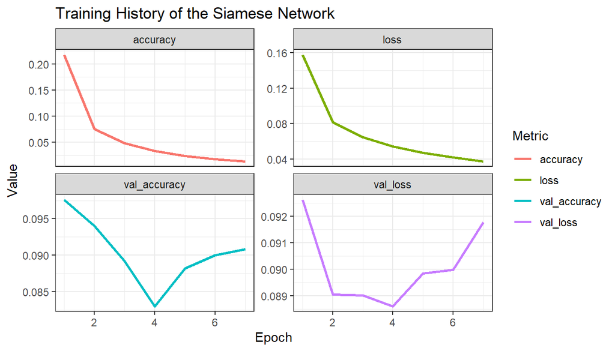

Figure 9: Training and validation loss of the Siamese network over training epochs.

The training loss decreased steadily from approximately 0.15 to 0.04, showing that the model learned the training data effectively. The validation loss decreased initially but then remained relatively constant, suggesting that the model generalised well with only slight signs of overfitting after the first few epochs.

### Threshold Selection

The Siamese network outputs a distance rather than a direct same-or-different prediction. A decision threshold was therefore selected using the validation set.

Distances below the threshold were classified as the same writer, while distances above the threshold were classified as different writers. The threshold that achieved the highest balanced accuracy on the validation set was chosen.

Threshold Selection Based on Validation Set Balanced Accuracy

| Threshold | Balanced_Accuracy | Selected |
| --- | --- | --- |
| 0.2512 | 0.7389 |  |
| 0.5328 | 0.9166 |  |
| 1.0923 | 0.7349 |  |
| 0.5103 | 0.9182 | ✓ Best |

### Evaluation of Matching Performance

The final model was evaluated on the independent test set from session 5. Matching performance was measured using:

- Accuracy: overall classification accuracy.
- True Positive Rate (Recall): same-writer pairs identified correctly.
- False Positive Rate: different-writer pairs misclassified as matches.
- False Negative Rate: same-writer pairs misclassified as non-matches.
- F1 Score: combined precision and recall.
- Area Under the ROC Curve (AUC): discrimination between matches and non-matches.

Table 4: Test Set Performance Metrics for the Siamese Network

| Metric | Value |
| --- | --- |
| Accuracy | 0.9138 |
| Recall (TPR / Sensitivity) | 0.9024 |
| Precision | 0.9207 |
| F1-Score | 0.9115 |
| False Positive Rate (FPR) | 0.0752 |
| False Negative Rate (FNR) | 0.0976 |
| AUC | 0.9727 |

Table 4 shows that the Siamese network achieved strong writer verification performance on the independent test set. Using the selected distance threshold, the model achieved an accuracy of 91.38%, indicating that most image pairs were classified correctly. The recall (90.24%) shows that the network successfully identified the majority of pairs written by the same writer, while the precision (92.07%) indicates that most pairs predicted as belonging to the same writer were correct. The F1-score of 91.15% demonstrates a good balance between precision and recall. Furthermore, the false positive rate (7.52%) and false negative rate (9.76%) were relatively low, suggesting that the model makes few matching errors.

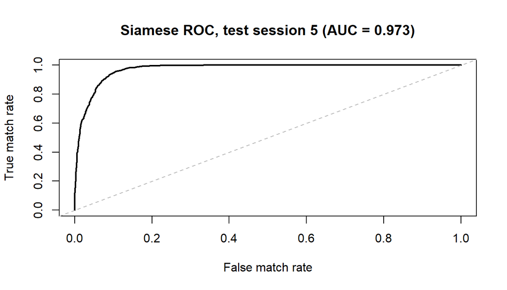

Figure 10: Siamese Network ROC

Figure 10 The ROC curve produced an AUC of 0.9727, indicating excellent discrimination between same-writer and different-writer pairs. Overall, the results suggest that the Siamese network learned a highly effective embedding space in which samples from the same writer are closer together than samples from different writers.

The Siamese network separated same-writer from different-writer pairs very well (AUC 0.973). Both models so far were trained on sessions 1–3, tuned on session 4 and tested on session 5. The way the data is split determines what a result actually measures, Section 4 compares the alternatives and explains why a session-based split was the optimal strategy.

## Section 4: Data Partition Strategy

### Candidate Strategy Critique

The provided dataset is structured across multiple distinct dimensions (writers, digits, recording sessions, and replicates), which allows for several potential train, validation, and test partitioning strategies. These include a standard random split, a split by individual writer, a split by digit, and a split by session. For this assessment, the most optimal strategy is to partition the dataset strictly by session.

### 1. The Random 80/20 Partition

Utilising a random 80/20 split will result in a split that is not dependent on writer, digit or session. However each writer wrote the exact same digits, 0 - 4, 50 times in a single session thus some of these identical replicates will be in the training set and others in the test set leading to severe spatial-temporal data leakage. Moreover, the performance metrics become heavily over-optimistic as the model simply memorizes specific pixel configurations it has already seen, rather than learning generalizable human writing styles.

### 2. Split by Individual Writer

In contrast, splitting by individual eliminates leakage as certain writers will never appear in the training pool. For example writers 1- 16 in the training pool and writers 17 - 20 in the test pool. This split is optimal for the Siamese network as it gives a non-optimistic view of verification - to authenticate if two completely unknown hands belong to the same person. However this split breaks the CNN classifier as the model cannot predict or classify the output for writer 17 with only having the output nodes for 1-16.

### 3. Split by Digit

Similarly, splitting the data by digit will result in the CNN model breaking. While training the model will learn a specific combination of strokes tied to specific character shapes however when presented with a new digit in test it will fail as the geometric structure of the number is foreign. However the Siamese network successfully handles a digit split as it bypasses discrete classification entirely and will take on the general style from the digits in training and apply that information to the test data.

### 4. Justification for the Session-Based Split

Overall, splitting the train and test data by session is the optimal strategy. This approach provides an identical, perfectly balanced evaluation ground for both the Siamese network and CNN. he CNN retains access to all 20 output classes, while the Siamese network can fairly evaluate similarity metrics across all 5 available digits. Furthermore, there is no optimistic bias or data leakage as session 5 is kept separate from the training loop. Lastly this strategy is optimal as it will be able to handle natural style drift over time (e.g., hand fatigue, mood changes, or stylus wear between sessions) by being trained on historical data (sessions 1 -3), validated on session 4, and tested on future data (Session 5) . This evaluation strategy represents a measure of the Temporal Style Generalisation within a Closed-Universe System. Thus by splitting by session all writers and all digits are preserved across both models.

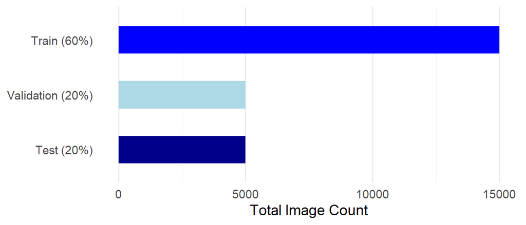

Figure 11: Chronological session partition blueprint

With the split fixed, session 4 can be used to make modelling choices without touching the test session. Section 5 uses it for a limited hyperparameter search for both models. It explores whether different settings would have improved the results of Sections 2 and 3 and, more importantly, how sensitive each model’s performance is to those choices.

## Section 5: Hyperparameter Tuning

### CNN Tuning

#### Search Design

The search considered 32, 64 and 128 dense units, together with learning rates of 0.0001, 0.0005 and 0.001, giving nine combinations. The original configuration of 128 dense units and a learning rate of 0.0001 was included as the baseline. The convolutional layers, dropout rate of 0.5, L2 penalty of 0.0001 and batch size of 64 were held fixed. Each model was trained for up to 15 epochs, with early stopping monitoring validation loss using patience of three epochs and restoration of the best weights. A fresh model and optimiser were created for each run, and the random seed was reset to 2026. These parameters were chosen because they affect different aspects of the model: dense-layer size changes the capacity of the final feature-combination stage, while learning rate controls the size of the Adam updates. The training curves in Section 2 showed overfitting, so smaller dense layers were included to test whether reducing capacity would improve performance on the validation session.

The session split was unchanged: sessions 1–3 were used for training, session 4 for validation and session 5 for the final test comparison. The accuracy of each restored model was measured on session 4. This is important because the epoch with the lowest validation loss need not have the highest validation accuracy. The largest accuracy observed anywhere in a training history would not necessarily describe the weights retained by early stopping.

#### Validation Results

Table 5: Validation performance of the nine CNN hyperparameter configurations.

| Dense units | Learning rate | Validation accuracy (%) | Validation loss | Selected epoch |
| --- | --- | --- | --- | --- |
| 128 | 0.0001 | 60.16 | 1.2992 | 3 |
| 128 | 0.0005 | 55.34 | 1.4135 | 1 |
| 128 | 0.0010 | 54.90 | 1.6606 | 1 |
| 32 | 0.0010 | 52.74 | 1.6244 | 1 |
| 32 | 0.0005 | 52.18 | 1.6216 | 2 |
| 32 | 0.0001 | 50.26 | 1.5902 | 5 |
| 64 | 0.0001 | 50.12 | 1.5142 | 3 |
| 64 | 0.0010 | 50.04 | 1.5831 | 1 |
| 64 | 0.0005 | 46.26 | 1.5519 | 1 |

Table 5 shows that the highest validation accuracy was **60.16%**, obtained with **128 dense units and a learning rate of 0.0001**. Its selected checkpoint was epoch 3, with validation loss of 1.2992. The search therefore selected the original Q2 configuration. The difference between the highest and lowest validation accuracies across the grid was 13.90 percentage points, showing that the choice of settings affected performance within the tested range.

#### Sensitivity to Dense-Layer Size and Learning Rate

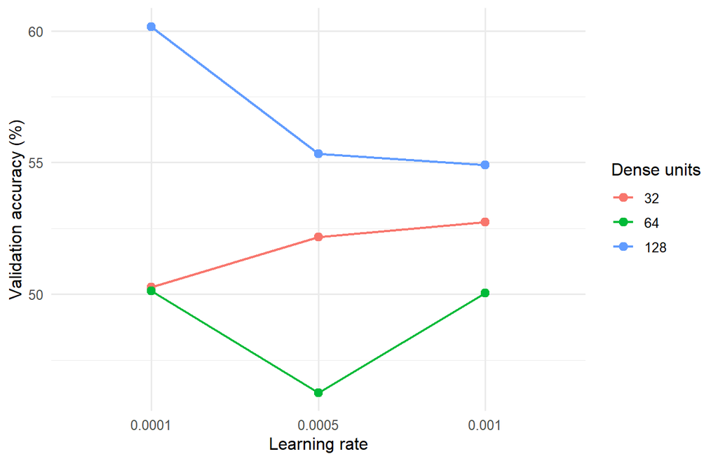

Figure 12: Validation accuracy across learning rates for each dense-layer size. All runs used seed 2026.

Dense-layer size had a noticeable effect on validation performance (Figure 12). The 128-unit model performed better than the 32- and 64-unit models at each of the three learning rates. At a learning rate of 0.0001, validation accuracy was 50.26% with 32 units, 50.12% with 64 units and 60.16% with 128 units. Reducing the dense-layer size therefore did not improve validation performance in these runs. Although the initial CNN showed overfitting, this does not imply that every reduction in model capacity will improve its ability to generalise.

The effect of learning rate depended on the dense-layer size. For the 128-unit model, increasing the learning rate from 0.0001 to 0.0005 reduced validation accuracy from 60.16% to 55.34%. Increasing it further to 0.001 gave 54.90%. In contrast, the 32-unit model improved from 50.26% at the lowest learning rate to 52.74% at the highest. The 64-unit model had its lowest accuracy at the intermediate learning rate. The differing trends indicate that the learning-rate effect should be considered together with model capacity, rather than assuming that one learning rate is uniformly better for all architectures.

#### Test Comparison with the Q2 Baseline

Table 6: Test accuracy of the baseline and validation-selected CNN configuration.

| Model | Test accuracy (%) |
| --- | --- |
| Q2 baseline | 65.54 |
| Q5 selected configuration | 63.30 |

The purpose of tuning was to compare plausible settings and assess sensitivity, rather than to guarantee an improvement. In this search, the alternative configurations did not outperform the original configuration on validation accuracy. Retaining the baseline was therefore supported by the observed validation results.

#### Limitations

This was a small, single-seed search over a specified grid. Resetting the seed made the procedure more repeatable, but it did not measure how the rankings might change with different initial weights or training randomness. There were also no repeated validation-session splits, so the results do not quantify sensitivity to the choice of held-out session.

### Siamese Network Tuning

#### Approach

We tuned the Siamese network from Task 3 using the same split as before: sessions 1–3 for training, session 4 for validation and session 5 for testing. Every setting was chosen using validation results only. Session 5 was used once, at the end, to report the chosen model’s performance.

We varied two hyperparameters:

- **Embedding size** (16, 32, 64): how many numbers each image is compressed into. A larger embedding can hold more detail about writing style, but has more to learn and can overfit.
- **Learning rate** (0.0001, 0.001, 0.01): how large a step the Adam optimiser takes on each update.

We trained one model for every combination (3 × 3 = 9 models). Every model used the same random seed, the same training, validation and test pairs, and early stopping on validation loss (patience 3, up to 20 epochs). Differences between models therefore come from the hyperparameters.

Models were compared using **AUC**: the probability that a randomly chosen same-writer pair gets a smaller distance than a randomly chosen different-writer pair.

[output not shown]

#### Results

Table 7: Grid search results, sorted by validation AUC. Gap = training AUC minus validation AUC.

| Embedding size | Learning rate | Epochs | Train AUC | Validation AUC | Test AUC | Gap |
| --- | --- | --- | --- | --- | --- | --- |
| 16 | 0.000 | 17 | 0.990 | 0.970 | 0.978 | 0.020 |
| 32 | 0.001 | 5 | 0.988 | 0.968 | 0.968 | 0.020 |
| 16 | 0.001 | 6 | 0.996 | 0.967 | 0.977 | 0.028 |
| 64 | 0.001 | 7 | 0.997 | 0.967 | 0.972 | 0.031 |
| 64 | 0.000 | 16 | 0.991 | 0.966 | 0.971 | 0.024 |
| 32 | 0.000 | 19 | 0.994 | 0.966 | 0.974 | 0.028 |
| 32 | 0.010 | 5 | 0.990 | 0.962 | 0.972 | 0.027 |
| 16 | 0.010 | 6 | 0.996 | 0.962 | 0.978 | 0.034 |
| 64 | 0.010 | 11 | 0.998 | 0.958 | 0.970 | 0.040 |

Table 8: Validation AUC by embedding size (rows) and learning rate (columns).

|  | 1e-04 | 0.001 | 0.01 |
| --- | --- | --- | --- |
| 16 | 0.970 | 0.967 | 0.962 |
| 32 | 0.966 | 0.968 | 0.962 |
| 64 | 0.966 | 0.967 | 0.958 |

#### Sensitivity

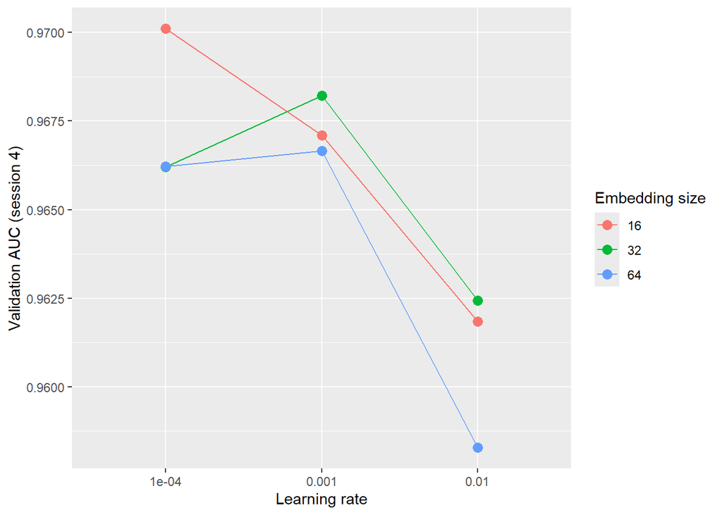

Figure 13: Sensitivity of validation AUC to learning rate and embedding size.

#### Final model

The final model reached a test AUC of 0.978. Moreover, it classified 93.2% of test pairs correctly. It accepted 95.7% of genuine same-writer pairs and wrongly accepted 9.3% of different-writer pairs.

Table 9: Final Siamese model: test performance (session 5).

| Measure | Value |
| --- | --- |
| AUC | 0.978 |
| Accuracy (cut-off chosen on validation) | 0.932 |
| True match rate (same writer correctly accepted) | 0.957 |
| False match rate (different writer wrongly accepted) | 0.093 |
| Distance cut-off | 0.516 |

Table 10: Final model: confusion table for the test pairs.

|  | Different | Same |
| --- | --- | --- |
| Different | 2305 | 105 |
| Same | 236 | 2354 |

Tuning showed a clear contrast between the two models. The CNN’s validation accuracy varied by 13.9 percentage points across its grid, while the Siamese network’s validation AUC varied by only 0.012. Section 6 brings the results together. It compares the two models directly and uses them to examine which digits carry the most writer information and how changes between sessions affect performance.

## Section 6: Comparing the CNN and Siamese Network

### Overall Comparison

Table 11: Test-set (session 5) results from Sections 2 and 3.

|  | CNN | Siamese network |
| --- | --- | --- |
| Task | Identification | Verification |
| Question answered | Which of the 20 writers wrote this image? | Were these two images written by the same person? |
| Chance level | 5% (1 in 20) | 50% accuracy, AUC 0.5 |
| Main result | Accuracy 65.5% | AUC 0.973, accuracy 91.4% |
| Other results | Cohen’s kappa 0.637 | True match rate 90.2%, false match rate 7.5% |

The two models solve **different tasks**, so their performance cannot be compared directly. The CNN performs identification and the Siamese network performs verification. A Siamese accuracy of 91.4% is therefore not evidence that it is a better model than a CNN with 65.5% accuracy; it was asked an easier question.

Each result is best judged against its own chance level. The CNN’s 65.5% is about 13 times better than guessing among 20 writers, and its kappa of 0.637 confirms substantial agreement beyond chance. The Siamese network’s AUC of 0.973 is close to the maximum of 1, meaning that in almost every comparison a same-writer pair received a smaller distance than a different-writer pair.

### Which Digits Carry More Writer Information?

To compare digits, each model is measured on its own task:

- **CNN:** writer identification accuracy for test images of each digit (from Section 2).
- **Siamese network:** verification AUC for test pairs in which **both** images show that digit. This measures how well the writer can be recognised from that digit alone.

Table 12: Writer information by digit (session 5). CNN: identification accuracy with 95% interval. Siamese: verification AUC for pairs where both images show that digit.

| Digit | CNN accuracy | CNN rank | Siamese AUC (same digit) | Siamese rank |
| --- | --- | --- | --- | --- |
| 0 | 63.4% ± 3.0 | 4 | 0.997 | 2 |
| 1 | 63.9% ± 3.0 | 3 | 0.997 | 4 |
| 2 | 61.9% ± 3.0 | 5 | 0.998 | 1 |
| 3 | 71.6% ± 2.8 | 1 | 0.997 | 3 |
| 4 | 66.9% ± 2.9 | 2 | 0.995 | 5 |

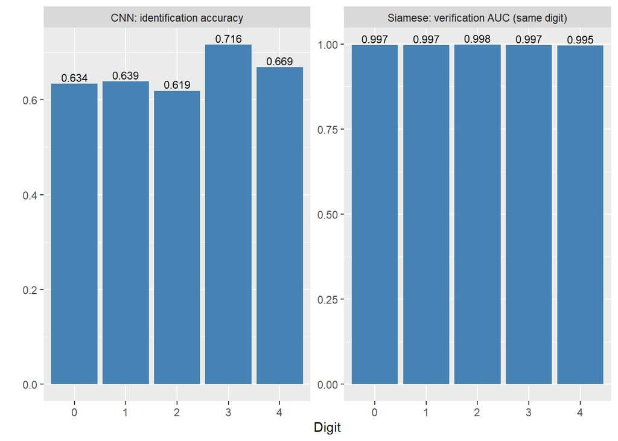

Figure 14: Writer information by digit for each model, on its own task (session 5).

For the CNN, the writer was easiest to identify from digit 3 and hardest from digit 2. For the Siamese network, same-digit matching was easiest for digit 2 and hardest for digit 4. The rank correlation between the two models’ digit results was -0.700.

Comparing the two models is what makes this a critical test. If a digit carries more information about who wrote it, **both** models should find it easier, even though they were trained differently and solve different tasks. Here the two models only partly agree, so any ranking of digits should be treated as tentative.

A clearer pattern appears when the two images show **different** digits. The Siamese AUC averaged 0.997 for same-digit pairs but 0.965 for different-digit pairs. Much of the writer information is therefore **digit-specific**: it is easier to tell whether two 3s share a writer than whether a 3 and a 0 do. When the digits differ, the model has to rely on style that carries across shapes, such as slant, stroke thickness and size, and that is weaker evidence. So the answer to “which digit carries the most writer information” depends on whether the comparison is made within one digit or across digits.

### How Session Changes Affect Performance

Table 13: Performance in each recording session, each model on its own task. Sessions 1-3 were used for training.

| Session | Role | CNN accuracy | Siamese AUC (both images from this session) |
| --- | --- | --- | --- |
| 1 | Training | 93.8% | 0.997 |
| 2 | Training | 93.5% | 0.997 |
| 3 | Training | 98.0% | 0.997 |
| 4 | Validation | 62.8% | 0.966 |
| 5 | Test | 65.5% | 0.971 |

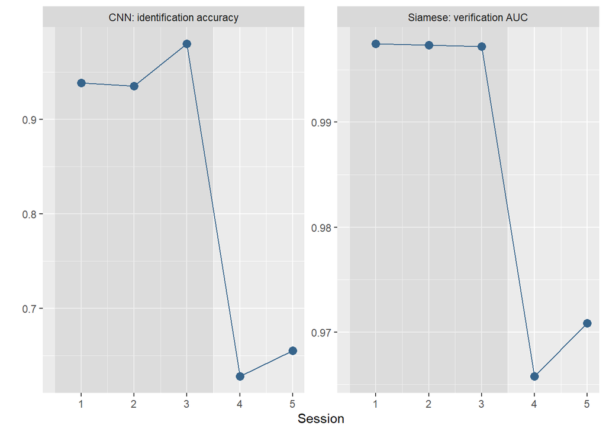

Figure 15: Performance by session for each model on its own task. The shaded area marks the training sessions.

**The CNN is strongly affected by session changes.** On the sessions it was trained on (1–3) it identified the writer 95.1% of the time; on the two new sessions (4–5) this fell to 64.2%, a drop of 30.9 percentage points. Sessions 4 and 5 performed similarly (62.8% and 65.5%). The loss therefore comes from moving to **any** unseen session, not from session 5 being unusual. The CNN partly learned what each writer’s handwriting looked like in those particular training sessions, rather than only the stable features that carry over. This matches the overfitting seen in Section 2, where training accuracy kept rising while validation accuracy levelled off.

**The Siamese network is much less affected.** Its AUC was 0.997 on average for the training sessions and 0.968 for the new sessions, a change of only 0.029. As it was trained to compare pairs rather than memorise 20 classes, it learned a more general notion of “same writer” that transfers to new sessions.

Table 14: Siamese AUC depending on which sessions the two images come from.

[output not shown]

In Section 3, both images in every test pair came from session 5. In practice, a new sample is usually compared with a reference collected **earlier**, as with a signature on file. When a session-5 image was compared with a reference from sessions 1–3, the AUC was 0.963, compared with 0.971 when both came from session 5. Comparing across sessions is harder, because the reference and the new sample differ by the session change as well as by normal variation. The within-session result in Section 3 is therefore an optimistic estimate of real-world verification performance. Moreover, Section 1 showed that replicates within a session are almost identical, so two images from the same writer and session can be near-copies. That makes within-session matching artificially easier, and the cross-session result is the more realistic measure.

Table 15: CNN: the five writers whose identification accuracy dropped most between the training sessions and session 5.

| Writer | Accuracy, sessions 1-3 | Accuracy, session 5 | Most often predicted as (session 5) |
| --- | --- | --- | --- |
| 5 | 99.9% | 0.0% | 13 |
| 13 | 92.5% | 2.8% | 5 |
| 10 | 100.0% | 26.0% | 2 |
| 16 | 98.9% | 53.6% | 16 |
| 8 | 99.2% | 54.8% | 8 |

Session changes did not affect all writers equally (Table 15). For 7 of the 20 writers, the CNN’s accuracy fell by more than 30 percentage points from the training sessions to session 5, while others were barely affected. For the worst cases, the CNN did not just become uncertain; it consistently assigned the writer’s session-5 images to **one other** writer (last column). This suggests that, for these people, the session change shifted their handwriting towards another writer’s style. Writer 5’s images being assigned to writer 13 (Section 2) is an example. A classifier with a fixed set of 20 classes is especially vulnerable to this: when a writer’s style shifts, their images fall into a neighbour’s class.

## Conclusion

This report compared two neural-network approaches to recognising writers from simulated handwritten digits. The CNN identified the correct writer from a single image 65.5% of the time, against 5% by chance. The Siamese network judged whether two images shared a writer with an AUC of 0.973.

Three findings stand out. First, **session changes were the main source of difficulty**. The CNN’s accuracy fell from 95.1% on its training sessions to 64.2% on new sessions, and its failures were concentrated on writers whose style shifted towards someone else’s. The Siamese network was far more robust, with AUC moving only from 0.997 to 0.968. Second, **writer information is largely digit-specific**: verification was stronger when both images showed the same digit (AUC 0.997) than when they showed different digits (0.965), while differences between individual digits were modest. Third, the Siamese network’s performance **changed very little across its hyperparameter grid**, whereas the CNN’s validation accuracy varied by several percentage points.

For a practical application, the Siamese approach is preferable. It is more robust to changes over time, can include new writers without retraining, and lets the decision cut-off be set according to the cost of each type of error. The analysis conclusions are limited due to the use of simulated data as well as near-replicates within sessions.Testing on writers never seen in training, and on real handwriting, would be the natural next steps.